# Tema I.5: Obtención de Datos

Autor/a

LÿRA  
L.RodriguezAragon@uclm.es

Fecha de publicación

22 de febrero de 2026

**Estadística (Grados en Ingeniería 2025 / 2026)**

Licesio J. Rodríguez Aragón  
Escuela Ing. Industrial y Aeroespacial de Toledo  
Departamento de Matemáticas  
Universidad de Castilla-La Mancha

## Bloque I: Estadística Descriptiva

# Tema I.5: Obtención de Datos [(p.206)](https://elibro.net/es/ereader/bibliotecauclm/60046?page=247)

[Lectura Introductoria](https://antonibosch.com/uploads/book_file/495_EC-FREEDMAN2_Capitulo1.pdf)

El análisis exploratorio de datos busca descubrir y resumir la información que contienen los datos utilizando gráficos y resúmenes numéricos. Las conclusiones que obtenemos del análisis de datos se refieren a los datos concretos que examinamos. **A menudo, sin embargo, queremos extender estas conclusiones a algún grupo mayor de individuos**. Para obtener respuestas sólidas es necesario diseñar la obtención de datos de forma adecuada.

> Autoevaluación I.5.1: Lee la introducción al [Capítulo 3](https://elibro.net/es/ereader/bibliotecauclm/60046?page=247) del libro. ¿Puedes pensar en alguna pregunta en ingeniería que podamos resolver recogiendo datos?

### Estudio Observacional frente a Experimental

- Un **estudio observacional** mide las variables de interés intentando no influir sobre las respuestas. [Ejemplo de estudio observacional](https://jamanetwork.com/journals/jamainternalmedicine/article-abstract/2723626).
- Sin embargo, un **experimento** somete de forma deliberada los individuos a algún tratamiento con el objetivo de observar sus respuestas. [Ejemplo de estudio experimental](https://doi.org/10.1016/j.cmet.2019.05.008) ([Preprint](https://osf.io/preprints/nutrixiv/w3zh2))

### Confusión:

Dos variables (variables explicativas o variables latentes) **se confunden** cuando sus efectos sobre una variable respuesta no se pueden distinguir entre sí.

**Ejemplos:**

- *Las máquinas que reciben más mantenimiento preventivo muestran un mayor número de averías registradas.* El ingeniero jefe concluye inicialmente: **El mantenimiento preventivo aumenta las averías. Deberíamos hacerlo menos.** (CONFUSIÓN: Edad de la máquina, cuanta más edad más revisiones y también más averías.)
- *Los equipos que funcionan con mayor temperatura media presentan más fallos electrónicos.* El ingeniero concluye: **La temperatura operativa causa los fallos. Debemos rediseñar la ventilación.** (CONFUSIÓN: Carga de trabajo: los equipos más exigidos trabajan más tiempo, más calientes y acumulan más fallos.)
- *Los vehículos de una flota que muestran mayor consumo de combustible tienen mayor tasa de averías del motor.* El ingeniero de flota concluye: **El consumo alto está dañando los motores.** (CONFUSIÓN: Tipo de ruta: rutas con más pendiente y uso intensivo provocan mayor consumo y más averías.)
- *Los satélites que realizan más maniobras de corrección orbital muestran una mayor probabilidad de fallos en sus actuadores.* El director de misión concluye: **Las maniobras frecuentes están deteriorando los actuadores. Debemos reducirlas.** (CONFUSIÓN: Órbita y entorno espacial: los satélites en órbitas más bajas o con mayor arrastre atmosférico necesitan más correcciones y también sufren mayor degradación mecánica y térmica, lo que explica los fallos.)

> Autoevaluación I.5.2: Intenta hacer por tu cuenta el Ejercicio [3.2](https://elibro.net/es/ereader/bibliotecauclm/60046?page=250).

### Población y Muestra:

- Un grupo entero de individuos sobre el que queremos información se llama **población**.
- Una **muestra** es la parte de la población que realmente examinamos con el objetivo de obtener información.
- **Diseño de muestra** se refiere al método utilizado para escoger la muestra de la población. Una mal diseño muestral nos puede llevar a conclusiones erróneas.

Una **muestra de voluntarios** consta de personas que se eligen a sí mismas en respuesta a un llamamiento general. Las muestras de voluntarios están sesgadas, ya que es fácil que estén formadas por gente muy motivada, especialmente de forma negativa.

**Ejemplos:**

- *Los voluntarios que responden valoran el curso como muy útil y bien estructurado.* Coordinación concluye: **El curso es ampliamente apreciado por el alumnado.** (SESGO DE VOLUNTARIADO: Responden sólo los estudiantes comprometidos, motivados que han completado el curso, mientras que los insatisfechos o indiferentes no participan.)
- *Los voluntarios que probaron el nuevo wearable lo encontraron intuitivo y fácil de configurar.* El equipo de diseño concluye: **El dispositivo es fácil de usar para cualquier consumidor.** (SESGO DE VOLUNTARIADO: Se apuntan quienes tienen más interés y más competencias tecnológicas, dejando fuera a usuarios mayores o con baja alfabetización digital.)

**Sesgo**: El diseño de un estudio es sesgado, si favorece sistemáticamente ciertos resultados. [Sesgo de Supervivencia](https://www.huffingtonpost.es/ansgar-seyfferth/estadistica-en-la-segunda-guerra-mundial-cuando-lo-importante-e_a_22107544/)

**Ejemplos:**

- *Las placas electrónicas que llegan al servicio técnico muestran fallos casi siempre en la etapa de potencia, pero rara vez en la etapa de control digital.* El responsable concluye: **La etapa de control digital es muy confiable; apenas falla.** (SESGO DE SUPERVIVENCIA: Muchas placas con defectos en la etapa digital no llegan al servicio técnico porque fallan en los tests de fábrica y se descartan antes de salir al mercado. Solo “sobreviven” las que tenían problemas en potencia.)
- *Los transformadores que llevan más de 30 años en servicio muestran tasas de fallo muy bajas.* El ingeniero concluye: **Los transformadores antiguos son más fiables que los modernos; deberíamos mantenerlos más tiempo en operación.** (SESGO DE SUPERVIVENCIA: Los transformadores antiguos que fallaron ya fueron retirados hace décadas. Solo “sobreviven” los ejemplares excepcionalmente robustos; no representan al conjunto de su generación.)
- *Los nanosatélites que completan más de 5 años en órbita presentan muy pocos fallos en sus baterías.* El analista concluye: **Las baterías espaciales duran mucho más de lo que se especifica.** (SESGO DE SUPERVIVENCIA: La mayoría de nanosatélites que tiene fallos prematuros de batería no alcanza los 5 años de vida, así que no entran en la muestra. Solo sobreviven los sistemas con baterías más robustas o en condiciones menos exigentes.)

> Autoevaluación I.5.3: Lee por tu cuenta los Ejemplos [3.2](https://elibro.net/es/ereader/bibliotecauclm/60046?page=252) y [3.3](https://elibro.net/es/ereader/bibliotecauclm/60046?page=252). Ilustran los problemas presentados por muestras de voluntarios y el sesgo. Intenta hacer por tu cuenta los Ejercicios [3.4, 3.5 y 3.6](https://elibro.net/es/ereader/bibliotecauclm/60046?page=253).

### Muestra Probabilística:

Una **muestra probabilística** da a cada individuo de la población una posibilidad conocida (mayor que cero de ser seleccionado): Todos los miembros de la población pueden formar parte de la muestra, disponemos de un censo.

### Muestra Aleatoria Simple:

Una **muestra aleatoria simple** de tamaño $n$ consta de $n$ individuos de una población escogidos de manera que cualquier conjunto de $n$ individuos de la población tenga las mismas posibilidades de ser la muestra realmente seleccionada: Los $n$ individuos se escogen al **azar**.

### Muestra Aleatoria Estratificada:

Para seleccionar una **muestra aleatoria estratificada**, divide en primer lugar la población en grupos de individuos similares, llamados estratos. Luego, escoge muestras aleatorias simples independientes en cada estrato y las combína para formar una muestra completa.

> Autoevaluación I.5.4: Lee el Ejemplo [3.5](https://elibro.net/es/ereader/bibliotecauclm/60046?page=260) presenta un ejemplo de muestreo estratificado para repartir los derechos de la Sociedad General de Autores.

### Falta de Cobertura y No-Respuesta:

La **falta de cobertura** ocurre cuando algunos grupos de la población se dejan fuera del proceso de selección de la muestra.

La **no-respuesta** ocurre cuando un individuo seleccionado en la muestra no puede ser contactado o rehúsa cooperar.

**Ejemplos:**

- *Un estudio de fiabilidad de transformadores solo incluye los equipos conectados a la red.* (FALTA DE COBERTURA: Los transformadores antiguos sin telemetría **nunca** pueden entrar en la muestra, y suelen ser precisamente los más propensos a fallos.)
- *En un estudio sobre calidad de suministro se envía una encuesta a responsables de subestaciones, pero un 40% no responde por exceso de carga de trabajo.* (NO RESPUESTA: Los responsables de subestaciones con más incidencias operativas son **los menos disponibles** para contestar, sesgando el resultado hacia zonas con menos problemas.)
- *Un análisis de fallos de placas electrónicas se basa únicamente en los equipos que llegan al servicio técnico.* (FALTA DE COBERTURA: Las placas que fallan en los test de fábrica **no entran** en la muestra; esto excluye fallos tempranos y produce un sesgo de “placas que sobreviven al control de calidad”.)
- *Se quiere estudiar la tasa de sobrecalentamiento de microcontroladores usando telemetría, pero algunos dispositivos no envían datos porque sus sensores fallan precisamente por exceso de temperatura.* (NO RESPUESTA: Los dispositivos más críticos **no responden** debido a la propia causa que se pretende estudiar, produciendo sesgo hacia valores optimistas.)
- *El análisis de fiabilidad se hace solo sobre los satélites que alcanzan órbita.* (FALTA DE COBERTURA: Se excluyen los que **fallan** durante el lanzamiento, sesgando la estimación hacia una fiabilidad superior.)
- *Un fabricante recopila datos de vibración de drones comerciales, pero un porcentaje significativo no sube los registros por fallos de conectividad o almacenamiento.* (NO RESPUESTA: Los drones con **fallos** estructurales, justo los de interés, son los menos probables de enviar información.)

### Inferencia sobre la población:

Es poco probable que los resultados de una muestra sean exactamente los mismos que los de toda la población.

Lo que ahora conviene destacar es que muestras **más grandes dan resultados más precisos que muestras más pequeñas**. Tomando una muestra muy grande puedes tener más seguridad de que el resultado muestral nos diga con más exactitud lo que ocurre con toda la población.

> Autoevaluación I.5.5: En la campaña electoral de 1936 en EEUU se realizó la primera encuesta electoral masiva de George Gallup, quien con una muestra de 5,000 individuos interrogados por todo el país predijo en que el vencedor de las elecciones sería Roosevelt. En paralelo la revista The Literary Digest lanzó una encuesta pidiendo a sus suscriptores enviar cupones anónimos indicando su candidato preferido en las elecciones, recibiendo dos millones de respuestas y dando como vencedor a Alf Landon. Busca información sobre las razones que marcaron las diferencias entre ambas encuestas. Lee el [Resumen 3.2](https://elibro.net/es/ereader/bibliotecauclm/60046?page=269).

¿Y en España? [¿Hay que ignorar las estimaciones de voto del… ?](https://archive.ph/C78Rh)

- Aragón 2026 (autonómicas, 8‑F)
  - Ganador: 34.3%.
  - CIS: 27.8% N = 3313.
  - SocioMétrica (para El Español) 35.7% N = 1000.
- Extremadura 2025 (autonómicas, 21‑D)
  - Ganador: 43.2%.
  - CIS: 38.5% N = 2037.
  - Target Point (para El Debate) 43.7% N = 1002.
- País Vasco 2024 (autonómicas, 21‑A)
  - Ganador: 35.2%.
  - CIS: 36.1% N = 4998.
  - EITB Focus 35.8% N = 1800.
- Cataluña 2024 (autonómicas, 12‑M)
  - Ganador: 28,0%.
  - CIS: 28.3% N = 8.905.
  - NC Report (para La Razón) 28.4% N = 1000.
- Europeas 2024 (España, 9‑J)
  - Ganador: 34,2%.
  - CIS: 27.9–30.2% N = 3458.
  - GAD3 (para Mediaset) 34.5% N = 1005.

[Los “errores” y “sesgos” del CIS…](https://maldita.es/malditateexplica/20250613/errores-encuestas-cis-tezanos/)

### Diseño de Experimentos:

Un estudio es realmente un experimento solamente cuando ejercemos alguna acción sobre personas, animales u objetos con el objetivo de observar sus respuestas.

- Los **individuos** con los que se hace un experimento son las **unidades experimentales**. Cuando éstas son seres humanos, se les llama sujetos.
- Una determinada **condición experimental** aplicada a las unidades experimentales se llama **tratamiento**.
- A las **variables explicativas** de un experimento se les suele llamar **factores**.

Muchos experimentos estudian los efectos conjuntos de varios factores. En este tipo de experimentos, un tratamiento está constituido por la combinación de los valores concretos de cada uno de los factores (a menudo llamados **niveles**).

**Ejemplos:**

- En un ramal radial de baja tensión se tratan **tramos de cable estandarizados** como unidades experimentales; se aplican tratamientos que combinan tres factores: **sección del conductor** (16/25/35 mm²), **estrategia de regulación** (sin regulación, OLTC primario, regulador de línea) y **perfil de carga** (base o pico), de modo que cada tratamiento es una combinación de niveles de esos factores. Tras aplicar el **tratamiento (cableado asignado, perfil y modo de regulación)**, se observan como variables de respuesta **las pérdidas (kWh), la caída de tensión, el THD y la temperatura del conductor**. El diseño es un factorial completo con bloqueo por **temperatura ambiente**, aleatorización del orden de ejecución de los experimentos y replicación para estimar el error.
- Las unidades experimentales son **placas buck** idénticas sobre las que se ejercen tratamientos definidos por la combinación de los factores: **tecnología de MOSFET (Si, SiC, GaN), estrategia de modulación (PWM fija o spread‑spectrum) y frecuencia de conmutación (150 o 600 kHz)**. Cada nivel configura una condición concreta del hardware/firmware y el tratamiento se aplica operando tres puntos de carga. Se miden como respuestas **la eficiencia, la temperatura de dispositivo, la EMI conducida y el rizado**, con un factorial completo y medidas repetidas por punto de carga, bloqueo por **lote de PCB** y aleatorización del orden para evitar sesgos.
- Los módulos **motor‑hélice** instrumentados son las unidades experimentales y reciben tratamientos definidos por la combinación de los factores: **perfil de pala (NACA A vs. perfil delgado optimizado), RPM (2.800 vs. 4.200) y densidad del aire (nivel del mar vs. 2.000 m equivalentes)**. Cada nivel fija una condición aeropropulsiva distinta; tras aplicar el tratamiento en banco de empuje se registran como respuestas **el empuje, la potencia eléctrica, la eficiencia (o figura de mérito) y el OASPL**. Se emplea un factorial completo con tres réplicas por tratamiento, **bloqueo por motor** y aleatorización del orden para asegurar inferencias válidas.

> Autoevaluación I.5.6: Lee detenidamente los Ejemplos [3.9 y 3.10](https://elibro.net/es/ereader/bibliotecauclm/60046?page=276). Ilustran la idea de factor y tratamiento. Intenta hacer por tu cuenta el Ejercicio [3.33](https://elibro.net/es/ereader/bibliotecauclm/60046?page=278).

### Diseño Completamente Aleatorizado:

En un **diseño experimental completamente aleatorizado**, todas las unidades experimentales se asignan al azar a todos los tratamientos.

Los diseños comparativos aleatorizados se designan para proporcionar evidencia de que diferencias en los tratamientos realmente causan las diferencias que vemos en las respuestas.

Su lógica es la siguiente:

- La asignación aleatoria de los sujetos debería formar **grupos similares** en todos los aspectos antes de aplicar los tratamientos.
- Los diseños comparativos garantizan que influencias distintas a las de los tratamientos experimentales afecten por igual a todos los grupos.
- Por tanto, las diferencias en las respuestas medias pueden ser debidas a los tratamientos o al papel del azar en la asignación aleatoria de los sujetos a los tratamientos.

> Autoevaluación I.5.7: Lee detenidamente el Ejemplo [3.13](https://elibro.net/es/ereader/bibliotecauclm/60046?page=282). Intenta hacer por tu cuenta el Ejercicio [3.36](https://elibro.net/es/ereader/bibliotecauclm/60046?page=284).

### Principios del Diseño de Experimentos

Los **principios básicos del diseño estadístico de experimentos** son

1. Control de los efectos de las variables latentes en la respuesta. La manera más simple es comparar varios tratamientos.
2. **Aleatorización**. La utilización del azar para asignar sujetos a los tratamientos.
3. **Replicación**. La replicación del experimento con muchos sujetos, con el fin de reducir el efecto del azar sobre la variación de los resultados.

La replicación de tratamientos en muchas unidades reduce el efecto de la variación del azar y hace que el experimento sea más sensible a las diferencias entre tratamientos.

### Significación Estadística:

Un efecto observado demasiado grande para ser atribuido sólo al azar se denomina **estadísticamente significativo**.

### Bloques y Diseños por Pares:

Los buenos experimentos exigen tanto prestar atención a los detalles como realizar un buen diseño estadístico. Muchos experimentos médicos u otros sobre el comportamiento de personas son **doblemente ciegos**. La falta de realismo de un experimento nos puede impedir generalizar sus resultados.

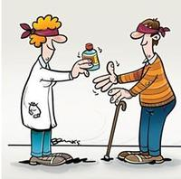

Simulación de un Experimento médico doblemente ciego

Además de la comparación, una segunda forma de control consiste en **restringir la aleatorización** formando **bloques** de unidades experimentales que son similares en aquellos aspectos que se estiman importantes para la respuesta.

La aleatorización se lleva a cabo, de forma independiente, dentro de cada uno de los bloques.

El **diseño por pares** es una forma habitual de diseño en bloques utilizado para comparar sólo dos tratamientos. En algunos diseños por pares cada sujeto recibe ambos tratamientos en orden aleatorio. En otros diseños, los sujetos se agrupan por pares lo más parecidos posible y un sujeto de cada par recibe cada tratamiento.

**Ejemplos:**

- En un ensayo para evaluar la durabilidad de interruptores automáticos de baja tensión ante microcortes repetitivos, se emplean **pares de interruptores emparejados por lote y capacidad nominal**, donde a uno se le aplica un tratamiento de microcortes generados por una fuente programable y al otro un patrón estándar; el técnico que aplica las secuencias no sabe cuál de los dos es el interruptor tratado **(primer ciego)** y el técnico que evalúa la degradación del mecanismo interno mediante pruebas dieléctricas y de disparo tampoco conoce qué unidad pertenece a qué grupo **(segundo ciego)**. La comparación por pares reduce la variabilidad debida al fabricante, mientras que el doble ciego garantiza que ni la aplicación de ciclos ni la evaluación del desgaste puedan sesgarse.
- Para estudiar si un nuevo barniz de protección (conformal coating) mejora la resistencia de placas electrónicas a la humedad cíclica, se forman **pares de PCBs iguales**, una recubierta con el barniz experimental y otra con el estándar comercial; se etiquetan únicamente con códigos opacos y se entregan a un operador que realiza los ciclos de humedad/temperatura sin conocer qué placa es cuál **(primer ciego)**, mientras que un segundo equipo mide la corriente de fuga, el aislamiento y la aparición de corrosión bajo lupa digital sin saber la asignación del tratamiento **(segundo ciego)**. El diseño por pares controla la variabilidad entre placas, y el doble ciego evita sesgos tanto en la exposición ambiental como en la evaluación eléctrica.
- En un experimento para comparar dos técnicas de impregnación de resina en paneles CFRP utilizados en estructuras aeronáuticas, cada panel del lote de fabricación se **empareja con otro de geometría y fibra idéntica** y se asigna aleatoriamente a la técnica convencional o a la nueva técnica experimental; los técnicos que realizan el curado en autoclave reciben paneles codificados sin saber el método aplicado **(primer ciego)**, y los inspectores que realizan ultrasonidos, identificación de delaminaciones y ensayos mecánicos post‑curado tampoco conocen la procedencia de cada panel **(segundo ciego)**. La evaluación por pares reduce la variabilidad de material, mientras que el doble ciego asegura objetividad tanto en la fabricación como en la caracterización estructural.

> Autoevaluación I.5.8: Lee detenidamente los Ejemplos [3.15](https://elibro.net/es/ereader/bibliotecauclm/60046?page=289) y [3.16](https://elibro.net/es/ereader/bibliotecauclm/60046?page=291). Intenta hacer por tu cuenta los Ejercicios [3.42](https://elibro.net/es/ereader/bibliotecauclm/60046?page=290) y [3.43](https://elibro.net/es/ereader/bibliotecauclm/60046?page=293).

### Curiosidades:

Estación agrícola experimental de [Rothamsted](http://www.rothamsted.ac.uk/)

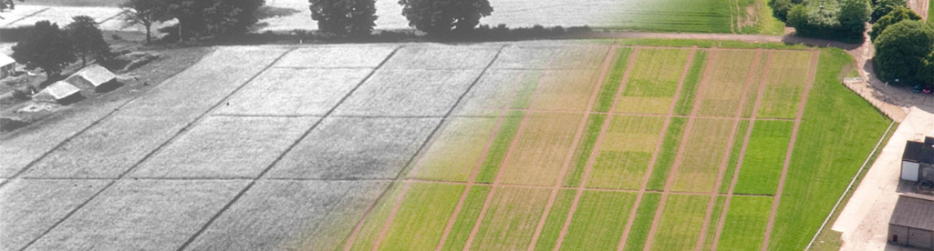

Evolución histórica de la Estación de Rothamsted

[Timbre Eléctrico de Oxford](https://en.wikipedia.org/wiki/Oxford_Electric_Bell)

[El Experimento de la Gota de Brea](https://es.wikipedia.org/wiki/Experimento_de_la_gota_de_brea)

> Autoevaluación I.5.9: Lee detenidamente el [Resúmen 3.4](https://elibro.net/es/ereader/bibliotecauclm/60046?page=2957) y el [Repaso del Capítulo 3](https://elibro.net/es/ereader/bibliotecauclm/60046?page=300). Ahora todos los [Ejercicios de Repaso del Capítulo 3](https://ebookcentral.proquest.com/lib/bibliotecauclm-ebooks/reader.action?ppg=302&docID=3202581&tm=1520101841779) están a tu alcance.